# TP_2

Alina Lopez

## Introducción

El presente documento utiliza como fuente de información primaria el dataset elaborado por el Gobierno de la Ciudad de Buenos Aires referido a la encuesta de uso del tiempo. Conforme a la publicación oficial, esta encuesta capta información que permite aproximar a la dimensión de la economía del cuidado y servir de base para la estimación del valor económico del trabajo no remunerado. Concretamente en relación al dataset, expresa la cantidad de horas diarias que los y las habitantes de la Ciudad de Buenos Aires le dedican a diferentes actividades, entre ellas: trabajo remunerado; labores domésticas; cuidado de niños, niñas; entre otros en el período 2016. Es importante resaltar que los datos son de carácter público lo que redunda en la obtención de información de calidad y pertinencia conforme a la población objetivo.

## Exploración de los datos

```r
usodeltiempo <- read_csv("datos/encuesta_uso_tiempo_2016.csv")
head(usodeltiempo)
```

```
## # A tibble: 6 × 27
##   hogar sexo   edad dia_laborable         trabajo_pago trabajo_domestico_no_pago
##   <chr> <chr> <dbl> <chr>                        <dbl>                     <dbl>
## 1 1_1   Varon    14 "D\xeda no laborable"            0                       0.1
## 2 2_1   Varon    14 "D\xeda no laborable"            0                       1
## 3 3_1   Varon    14 "D\xeda no laborable"            0                       0.2
## 4 4_1   Varon    14 "D\xeda no laborable"            0                       1.8
## 5 5_1   Varon    14 "D\xeda no laborable"            0                       0
## 6 6_1   Mujer    14 "D\xeda no laborable"            0                       3
## # ℹ 21 more variables: voluntariados <dbl>, estudio_educacion <dbl>,
## #   recreacion <dbl>, aplicaciones <dbl>, tareas_cuidados <dbl>,
## #   cuidado_personal <dbl>, trabajo_pago2 <dbl>,
## #   trabajo_domestico_no_pago2 <dbl>, voluntariados2 <dbl>,
## #   estudio_educacion2 <dbl>, recreacion2 <dbl>, aplicaciones2 <dbl>,
## #   tareas_cuidados2 <dbl>, cuidado_personal2 <dbl>, dia_tipico <chr>,
## #   rango_etario <chr>, nivel_educativo <chr>, …
```

El data set cuenta con 2336 observaciones, distribuidas en 27 columnas tales como edad,estudio, tareas de cuidado, trabajo pago, ocupación entre otras. Con el propósito de conocer algunas de las características descriptivas de la población encuestada, se presenta a continuación los siguientes hallazgos:

**Distribución de la población encuestada según sexo**

```r
usodeltiempo |>
  group_by(sexo) |>
  summarise(n = n()) |>
  arrange(desc(n))
```

```
## # A tibble: 2 × 2
##   sexo      n
##   <chr> <int>
## 1 Mujer  1345
## 2 Varon   991
```

Tal como lo muestra la información precedente, la población encuestada se compone de 1345 mujeres y 991 varones. De acuerdo a la información publicada en el Anuario Estadístico de la Ciudad de Buenos Aires de 2016 -el mismo año que se realizó la encuesta uso del tiempo- la población total ascendía a 3.059.122 habitantes, de los cuales 1.430.531 eran varones y 1.628.591 eran mujeres (vease https://www.estadisticaciudad.gob.ar/eyc/wp-content/uploads/2017/10/anuario_estadistico_2016.pdf cuadro 1.9)

Si se toma como parámetro de comparación la tasa de masculinidad que consiste en dividir la cantidad de varones sobre la cantidad de mujeres, se obtiene que para los casos contemplados en el dataset de uso del tiempo es de 73,68%; mientras que para la población total es de 87,83%. Es decir, en cuanto a la relación con la población total de la ciudad, la muestra está sesgada al tener una proporción mayor de mujeres.

**Distribución por nivel educativo**

A continuación se expresa cómo se distribuye la población por nivel educativo

```r
usodeltiempo |>
  group_by(nivel_educativo) |>
  summarise(n = n()) |>
  arrange(desc(n))
```

```
## # A tibble: 4 × 2
##   nivel_educativo                             n
##   <chr>                                   <int>
## 1 Secundario completo/Superior incompleto   977
## 2 Superior completo                         861
## 3 Secundario incompleto                     496
## 4 Escuela especial                            2
```

Es posible afirmar que la mayor parte de la población encuestada tiene cursados sus estudios de nivel secuendario, seguido por formación superior completa.

**Caracterizaciones por edad**

En relación a la edad, es importante señalar que el dataset presenta información de dos maneras: las distribución de edades tal como fueron respondidas por las personas encuestadas y la distribución por intervalos. Esto permite inferir que la base de datos tuvo un procedamiento previo con el propósito de facilitar el acceso a la información. A continuación se presentan los datos referidos a las edades de las personas encuestadas:

```r
usodeltiempo |>
  group_by(rango_etario) |>
  summarise(n = n()) |>
  arrange(desc(n))
```

```
## # A tibble: 5 × 2
##   rango_etario     n
##   <chr>        <int>
## 1 25-39          672
## 2 65+            545
## 3 50-64          521
## 4 40-49          307
## 5 14-24          291
```

La mayor proporción de la población encuestada tiene entre 25 y 39 años de edad. Asimismo de la información anterior se desprende que la edad mínima de la persona a encuestar es de 14 años. No obstante, si se quiere saber la edad máxima es necesario procesar la información como se detalla más abajo.

```r
usodeltiempo |>
  summarise(max_edad = max(edad))
```

```
## # A tibble: 1 × 1
##   max_edad
##      <dbl>
## 1       97
```

Es decir que la persona con mayor edad encuestada es del 97 años.

**Aspectos ocupacionales**

```r
usodeltiempo |>
  group_by(estado_ocupacional) |>
  summarise(n = n()) |>
  arrange(desc(n))
```

```
## # A tibble: 3 × 2
##   estado_ocupacional     n
##   <chr>              <int>
## 1 Ocupado             1607
## 2 Inactivo             637
## 3 Desocupado            92
```

En relación a la condición de ocupación, la mayoria de la población tenía una ocupación laboral al momento de realizar la encuesta.

**Información referida a los hogares de las personas encuestadas**

Al intentar conocer acerca de la composición de los ingresos del hogar, la información arroja un resultado llamativo:

```r
usodeltiempo |>
   group_by(quintil_ingreso) |>
  summarise(n = n()) |>
  arrange(desc(n))
```

```
## # A tibble: 1 × 2
##   quintil_ingreso     n
##   <chr>           <int>
## 1 5to quintil      2336
```

Resulta extraño que todas las personas encuestadas manifiestan tener ingresos que refieren al quinto quintil. A tal efecto, se realizó una consulta al area de Estadísticas del Gobierno de la Ciudad de Buenos Aires y admitieron el error en la muestra. No obstante al momento de elaboración del presente documento, la base disponible sigue conteniendo el mismo error. Por ello, se desestima la caracterización referida al nivel socioeconómico de los hogares.

```r
usodeltiempo |>
   group_by(tipo_hogar) |>
  summarise(n = n()) |>
  arrange(desc(n))
```

```
## # A tibble: 4 × 2
##   tipo_hogar                        n
##   <chr>                         <int>
## 1 Nuclear con nucleo completo    1045
## 2 Unipersonal                     759
## 3 Otro                            300
## 4 Nuclear con nucleo incompleto   232
```

**Datos vinculados a la distribución de las tareas de cuidado al interior de los hogares**

Según lo presentado en los párrafos anteriores, la encuesta de uso del tiempo se implementa con el propósito de conocer la distribución de las tareas de cuidado al interior de los hogares. Asimismo se reitera que este relevamiento se llevo a cabo en la Ciudad Autónoma de Buenos Aires en el año 2016 y se toma como unidad de medida las horas requeridas para llevar a cabo tales tareas. En virtud de ello, se presenta a continuación algunos datos que permiten conocer dicha distribución:

```r
usodeltiempo |>
    group_by(sexo) |>
  summarise(tiempo_prom_cuid = mean(tareas_cuidados, na.rm = TRUE))
```

```
## # A tibble: 2 × 2
##   sexo  tiempo_prom_cuid
##   <chr>            <dbl>
## 1 Mujer             1.53
## 2 Varon             0.7
```

La tabulación anterior arroja un resultado un tanto llamativo en cuento a la distribución propuesta. No pareciera ser un dato válido que las mujeres destinen tan solo 1.5 horas a las tareas de cuidado. Por ello, es necesario conocer como está compuesta esa columna:

```r
usodeltiempo |>
  group_by(tareas_cuidados) |>
  summarise(n = n()) |>
  arrange(desc(n))
```

```
## # A tibble: 129 × 2
##    tareas_cuidados     n
##              <dbl> <int>
##  1             0    1801
##  2             1      27
##  3             4      23
##  4             2      22
##  5             3      22
##  6             0.5    21
##  7             1.5    17
##  8             2.5    13
##  9             3.5    13
## 10             1.3    12
## # ℹ 119 more rows
```

Conforme a la información precedente, se observa que la abrumadora mayoria de observaciones están en el valor “0”, lo que redunda en una significativa reducción del promedio. Esta situación puede deberse a:

1. no se tiene el dato de referencia.
2. la persona encuestada no tiene otras personas a cargo al momento que le realizaron la encuesta.
3. la persona respondió que no le dedica horas a las tareas de cuidados.

En relación al punto b, no hay en la base información que permita discriminar a las personas que tienen otras personas a cargo de las que no. Por ello, una alternativa posible es tomar los datos mayores a ese valor para observar si se obtiene un resultado diferente:

```r
usodeltiempo |>
  group_by(sexo) |>
  filter(tareas_cuidados >0)|>
  summarise(tiempo_prom_cuid = mean(tareas_cuidados, na.rm = TRUE))
```

```
## # A tibble: 2 × 2
##   sexo  tiempo_prom_cuid
##   <chr>            <dbl>
## 1 Mujer             5.85
## 2 Varon             3.77
```

El tabulado anterior expresa información más acertada en relación a la distribución de las tareas de cuidado. En efecto, en promedio las mujeres encuestadas destinan mayor carga horaria en las tareas de cuidado de personas, 5,8 frente a 3,7 horas de los varones. No obstante, se reitera la aclaración que no fueron tenidos en cuenta los casos que tienen valor “0” en esa variable y que dichos casos representan 1801 de 2336 observaciones, reduciendo considerablemente la muestra de donde se extrajo esa información.  
Por ello, resulta importante complementar los datos obtenidos con otros análisis para tener una mirada de mayor integralidad.

De hecho, si se toman la cantidad de horas dedidacas al trabajo doméstico no pago según sexo, se visualiza la siguiente relación:

```r
usodeltiempo |>
    group_by(sexo) |>
  summarise(tiempo_prom_dom_nopag = mean(trabajo_domestico_no_pago, na.rm = TRUE))
```

```
## # A tibble: 2 × 2
##   sexo  tiempo_prom_dom_nopag
##   <chr>                 <dbl>
## 1 Mujer                  3.14
## 2 Varon                  1.81
```

Conforme a la información anterior, en relación al tiempo promedio dedicado al trabajo doméstico no remunerado, las mujeres casi duplican la cantidad de horas en relación a los varones. En este caso en el dataset, no figuran tantos valores en “0” como en el caso anterior, por eso se mantiene considerando todos los valores:

```r
usodeltiempo |>
  group_by(trabajo_domestico_no_pago) |>
  summarise(n = n()) |>
  arrange(desc(n))
```

```
## # A tibble: 116 × 2
##    trabajo_domestico_no_pago     n
##                        <dbl> <int>
##  1                       0     258
##  2                       0.5   112
##  3                       0.3    94
##  4                       1      91
##  5                       0.2    79
##  6                       1.3    76
##  7                       0.8    71
##  8                       1.5    70
##  9                       2      66
## 10                       2.5    58
## # ℹ 106 more rows
```

Si se analizan los datos vinculados a la carga horaria destinada a labores voluntarias y las de trabajo remunerado se obtiene la siguiente información:

```r
usodeltiempo |>
  group_by(voluntariados) |>
  summarise(n = n()) |>
  arrange(desc(n))
```

```
## # A tibble: 69 × 2
##    voluntariados     n
##            <dbl> <int>
##  1           0    2106
##  2           1      18
##  3           1.5    16
##  4           2      14
##  5           4      13
##  6           3      11
##  7           5      11
##  8           2.5    10
##  9           5.5     9
## 10           0.8     8
## # ℹ 59 more rows
```

```r
usodeltiempo |>
  group_by(trabajo_pago) |>
  summarise(n = n()) |>
  arrange(desc(n))
```

```
## # A tibble: 140 × 2
##    trabajo_pago     n
##           <dbl> <int>
##  1          0    1162
##  2          9      46
##  3          8      40
##  4          8.8    37
##  5          9.5    34
##  6          8.5    29
##  7          9.8    29
##  8          7      28
##  9          8.3    28
## 10          9.3    27
## # ℹ 130 more rows
```

```r
usodeltiempo |>
  group_by(sexo) |>
  filter(voluntariados >0)|>
  summarise(tiempo_prom_vol = mean(voluntariados, na.rm = TRUE))
```

```
## # A tibble: 2 × 2
##   sexo  tiempo_prom_vol
##   <chr>           <dbl>
## 1 Mujer            4.16
## 2 Varon            4.11
```

```r
usodeltiempo |>
    group_by(sexo) |>
   filter(trabajo_pago >0)|>
  summarise(tiempo_prom_pago = mean(trabajo_pago, na.rm = TRUE))
```

```
## # A tibble: 2 × 2
##   sexo  tiempo_prom_pago
##   <chr>            <dbl>
## 1 Mujer             8.01
## 2 Varon             8.86
```

De acuerdo a la información precedente, no se observan diferencias significativas en relación a la distribución por sexo en cuanto al tiempo promedio de horas dedicadas al trabajo remunerado y labores voluntarias.

Concretamente en relación a los datos, se considera que la información presentada resulta útil para visualizar las diferencias en cuanto a la distribuciones de las tareas vinculadas a la economía del cuidado, pero es igual de importante explicitar cuáles fueron las decisiones que se fueron tomando durante el procesamiento de la información para realizar dichas conclusiones.

Para finalizar se presenta la distribución de las responsabilidades de cuidado y trabajo doméstido en forma graficada. No se tomaron en cuenta otras distribuciones debido a la escasa diferencia entre los valores.

**Gráficos**

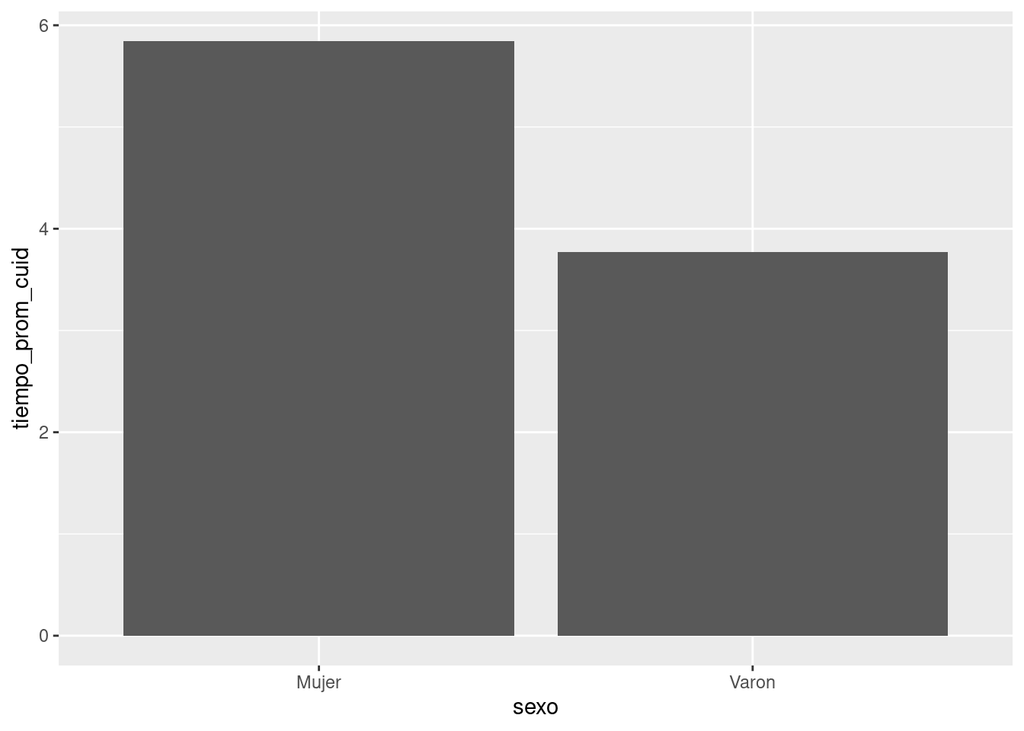

```r
library(ggplot2)

usodeltiempo |>
  group_by(sexo) |>
  filter(tareas_cuidados >0)|>
  summarise(tiempo_prom_cuid = mean(tareas_cuidados, na.rm = TRUE))|>
ggplot(aes(sexo, tiempo_prom_cuid)) +
  geom_col()
```

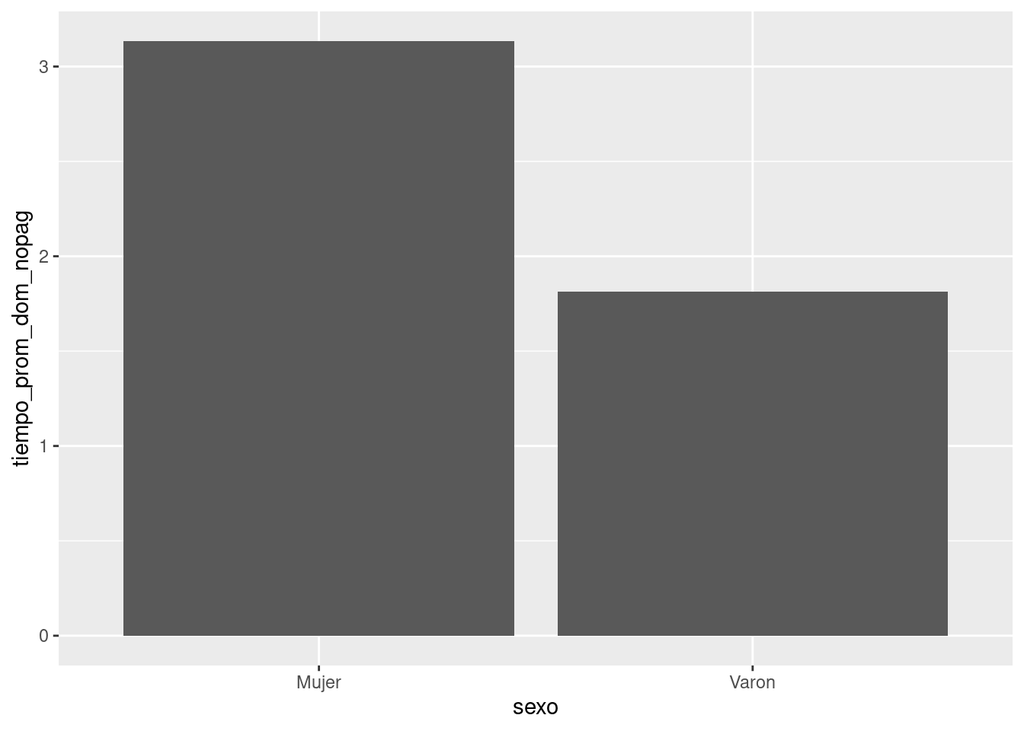

```r
usodeltiempo |>
  group_by(sexo) |>
  summarise(tiempo_prom_dom_nopag = mean(trabajo_domestico_no_pago, na.rm = TRUE))|>
ggplot(aes(sexo, tiempo_prom_dom_nopag)) +
  geom_col()
```

## Hipótesis

A modo de hipótesis, es posible plantear los siguientes interrogantes:

**Hipótesis 1** ¿Las mujeres jóvenes destinan en promedio mayor carga horaria a las tareas de cuidado que las mujeres adultas?¿y en relación al trabajo en el hogar no remunerado?

```r
usodeltiempo |>
  group_by(rango_etario) |>
   filter(tareas_cuidados >0)|>
  summarise(tiempo_prom_cuid = mean(tareas_cuidados, na.rm = TRUE))
```

```
## # A tibble: 5 × 2
##   rango_etario tiempo_prom_cuid
##   <chr>                   <dbl>
## 1 14-24                    4.79
## 2 25-39                    5.91
## 3 40-49                    4.42
## 4 50-64                    4.32
## 5 65+                      4.63
```

En cuanto a la distribución general, la relación entre rango etario y promedio de horas destinadas a las tareas de cuidado se visualiza en forma más clara para las personas entre 25 y 39 años. Se presenta a continuación la información diferennciada por sexo.

```r
 usodeltiempo |>
group_by(rango_etario) |>
   filter(tareas_cuidados >0,  sexo == "Mujer")|>
  summarise(tiempo_prom_cuid = mean(tareas_cuidados, na.rm = TRUE))
```

```
## # A tibble: 5 × 2
##   rango_etario tiempo_prom_cuid
##   <chr>                   <dbl>
## 1 14-24                    5.96
## 2 25-39                    6.93
## 3 40-49                    4.94
## 4 50-64                    4.32
## 5 65+                      4.29
```

Las mujeres de 25 a 39 años son las que destinan en promedio la mayor cantidad de horas para tareas de cuidado de personas. Este rango etario se corresponde con la tasa de fecundidad. En efecto, en la Ciudad de Buenos Aires es de 94,4 por mil (vease Anuario Estadístico Ciudad de Buenos Aires, cuadro 2.23).

Se presenta a continuación los resultados para los varones

```r
usodeltiempo |>
group_by(rango_etario) |>
   filter(tareas_cuidados >0,  sexo == "Varon")|>
  summarise(tiempo_prom_cuid = mean(tareas_cuidados, na.rm = TRUE))
```

```
## # A tibble: 5 × 2
##   rango_etario tiempo_prom_cuid
##   <chr>                   <dbl>
## 1 14-24                    2.35
## 2 25-39                    3.89
## 3 40-49                    3.23
## 4 50-64                    4.31
## 5 65+                      5.14
```

Seguidamente se presenta la información referida a las tareas de trabajo doméstico por rango etario según sexo.

```r
usodeltiempo|>
  group_by(rango_etario) |>
   filter(trabajo_domestico_no_pago >0,  sexo == "Mujer")|>
  summarise(tiempo_prom_nopag = mean(trabajo_domestico_no_pago, na.rm = TRUE))
```

```
## # A tibble: 5 × 2
##   rango_etario tiempo_prom_nopag
##   <chr>                    <dbl>
## 1 14-24                     1.70
## 2 25-39                     2.87
## 3 40-49                     3.37
## 4 50-64                     3.70
## 5 65+                       4.31
```

A diferencia de las tareas de cuidado de persona, el rango etario donde las mujeres destinan en promedio mayor carga horaria es a partir de los 65 años. Se presenta más abajo los datos para los varones:

```r
usodeltiempo |>
  group_by(rango_etario) |>
   filter(trabajo_domestico_no_pago > 0,  sexo == "Varon") |>
     summarise(prom_trabnopag = mean (trabajo_domestico_no_pago , na.rm = TRUE))
```

```
## # A tibble: 5 × 2
##   rango_etario prom_trabnopag
##   <chr>                 <dbl>
## 1 14-24                  1.30
## 2 25-39                  1.96
## 3 40-49                  2.12
## 4 50-64                  2.31
## 5 65+                    2.76
```

A modo de conclusión, conforme a los datos presentados, es posible enunciar que existe una clara relación entre edad y tareas de cuidados de personas para las mujeres. A su vez, el rango etario que las mujeres mayormente destinan en promedio de horas al cuidado de personas se corresponde con la tasa de fecundidad. Dicha situación permite reflexionar acerca de la incidencia de los estereotipos tradicionales de género en las distribución d las tareas de cuidado. Se presenta a continuación interrogantes adicionales para complementar la reflexión.

**Hipótesis 2**

Otro de las preguntas surgidas a partir de la exploración de datos gravita en la relación entre las horas trabajadas para el mercado laboral y las horas destinadas a las tareas de cuidado. Es decir, ¿las mujeres que trabajan mayor cantidad de hs en el mercado destinan menor cantidad de hs a a las tareas de cuidado de personas que las que trabajan menos horas? ¿Esta relación se mantiene para el caso de los varones?

En virtud de los interrogantes antes mencionados, se grafican a continuación dichas relaciones:

2.1. Relación entre trabajo pago y tareas de cuidados para las mujeres:

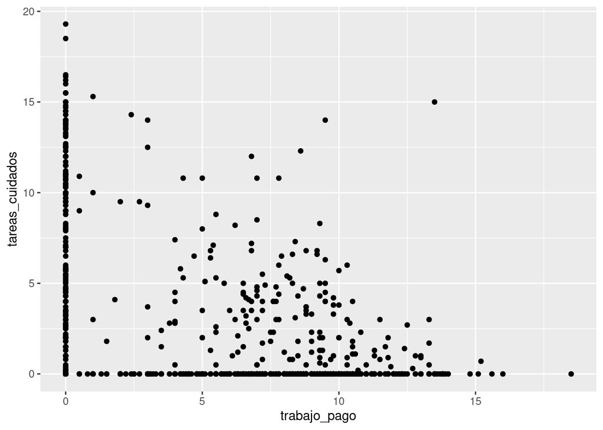

```r
usodeltiempo |>
filter(sexo== "Mujer")  |>
  ggplot(aes(trabajo_pago, tareas_cuidados)) +
  geom_point()
```

Si bien la cantidad de casos en valor “0” tanto para las horas trabajadas fuera del hogar como para las destinadas a las tareas de cuidados es notable, se visualiza cierta concentración de casos cuanto mayor son las hs destinadas al trabajo pago y menores las destinadas a las tareas de cuidado. Esta situación puede deberse a:

1. Las mujeres que destinan mayor carga horaria a trabajar para el mercado viven en hogares con una distribución compartida de tareas de cuidado. Esto puede deberse a que cuentan con recursos económicos que les permiten contratar a terceras personas o espacios que brindan esos cuidados o bien porque hay una redistribución equitativa de las tareas de cuidado al interior de la configuración familiar.
2. Asimismo, como contrapartida de esta situación, las mujeres que destinar mayores horas al cuidado de personas son quienes menos horas pueden trabajar para el mercado. Esta situación habilita a reflexionar acerca la existencia de obstáculos de incidencia en las trayectorias laborales de las mujeres a raiz del desempeño de tareas de cuidado de personas.

2.2. Relación entre trabajo pago y tareas de cuidados para los varones:

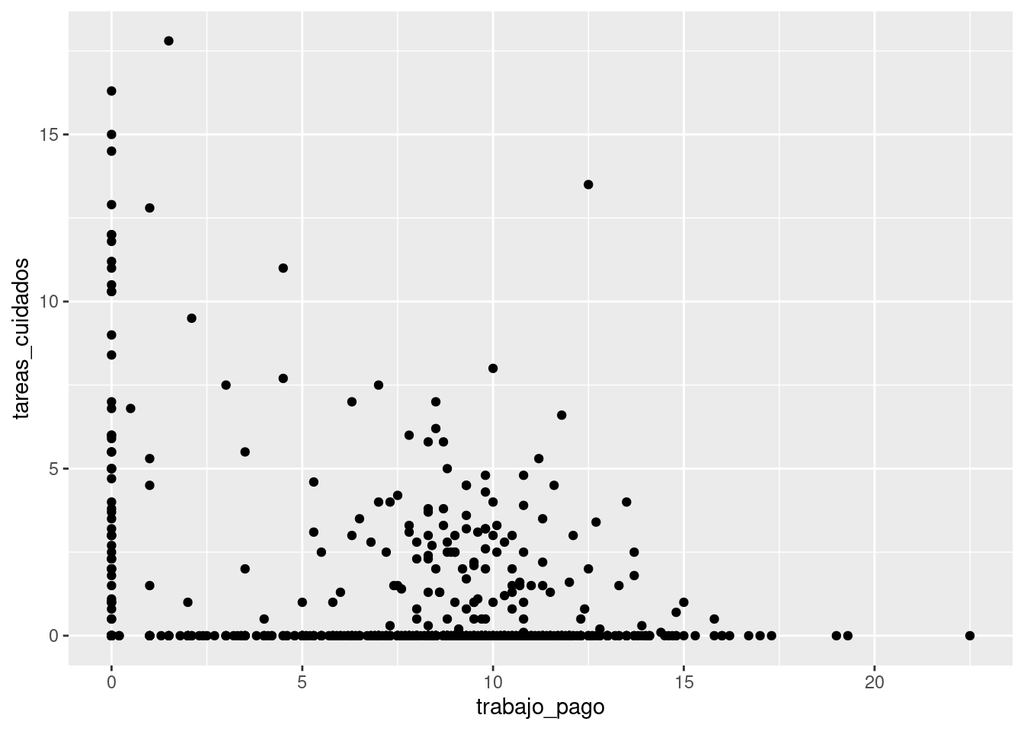

```r
usodeltiempo |>
filter(sexo== "Varon")  |>
  ggplot(aes(trabajo_pago, tareas_cuidados)) +
  geom_point()
```

A diferencia de las mujeres, no parece visualizarse una relación muy afin entre las horas destinadas al mercado y las horas destinadas a las tareas de cuidado. La concentración de casos de visualiza en el rango de 5 a 10 hs de trabajo pago y en el valor “0” para las tareas de cuidado.

**Algunas consideraciones finales**

los interrogantes formulados se desarrollaron con el propósito de reflexionar sobre la desigual distribución de las tareas de cuidado de personas y hogares para hombres y mujeres. El análisis de los datos encontrados permite dar cuenta de la incidencia de estereotipos tradicionales de género que estructuran la división sexual trabajo asignando tareas para varones y mujeres. Dichas labores resultan claramente diferenciadas y gravitan en el uso de sus tiempos. No obstante es importante señalar que dicha información brinda una respuesta parcial a la problemática que debiera ser complementada por otros recursos.